# R Project en Experimentación Animal

Actividad 3

Edimer David Jaramillo

2021-08-27

# Actividad

- **Nota:** las bases de datos suministradas en cada punto pueden estar estructuradas de manera incorrecta, de ser así, usted deberá dar solución a las dificultades que identifique en cada conjunto de datos.

## Punto 1 (25%)

- Formule mínimo 3 consultas o preguntas a la base de datos de [Evaluaciones Agropecuarias Municipales – EVA. 2019 - 2020](https://www.datos.gov.co/Agricultura-y-Desarrollo-Rural/Evaluaciones-Agropecuarias-Municipales-EVA-2019-20/p5fp-pay3) y utilice un gráfico en cada una de ellas para mostrar la solución. Es importante que las tres consultas tengan alguna relación.

## Punto 2 (25%)

- Descargue la base de datos de [PIB Tasa de Crecimiento del Valor Agregado Segun Actividad Economica](https://www.datos.gov.co/Econom-a-y-Finanzas/PIB-Tasa-de-Crecimiento-del-Valor-Agregado-Segun-A/kdg6-42a4) y replique el siguiente gráfico:

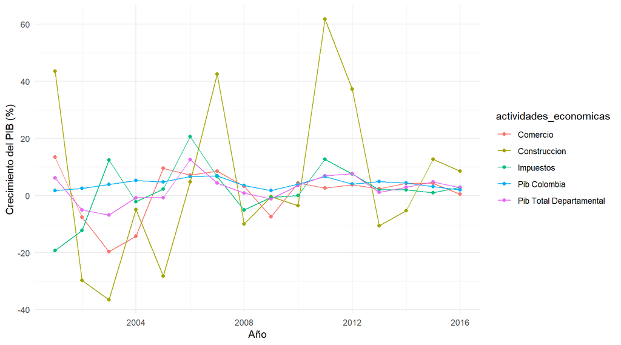

## Punto 3 (25%)

- Con la base de datos de las [1000 Empresas mas grandes del país](https://www.datos.gov.co/Econom-a-y-Finanzas/1000-Empresas-mas-grandes-del-pa-s/8hn7-rpp8) construya un gráfico donde muestre cuáles son las 10 empresas con mayor ingreso operacional del 2018 y cuánto representa ese ingreso (en términos porcentuales) del total de ingresos operaciones para el mismo año.

## Punto 4 (25%)

- Con la base de datos [Copacabana - Accidentes por lugar y tipo](https://www.datos.gov.co/Transporte/Copacabana-Accidentes-por-lugar-y-tipo/ggfx-n9ra) replique el siguiente gráfico:

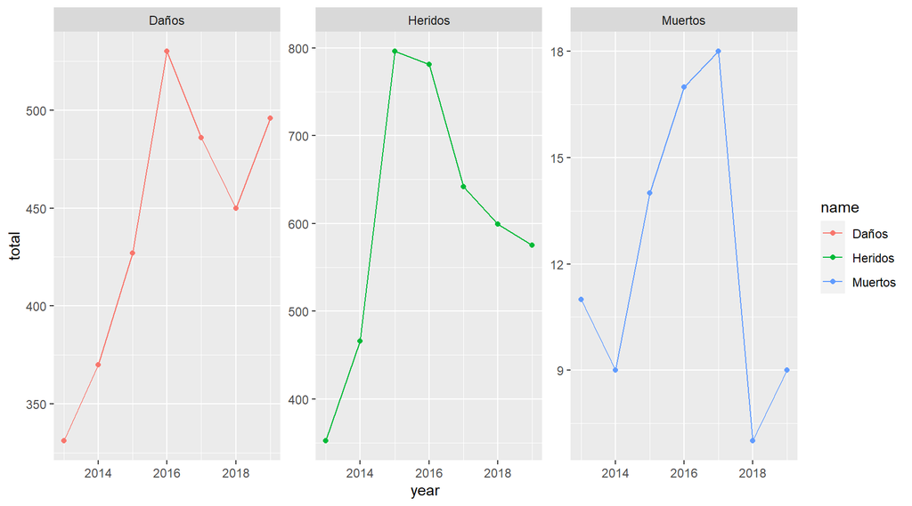

# Fecha de entrega

- Máximo el 10 de septiembre de 2021 antes de las 11:59 pm.